# Work Practices and Perceptions from Women Core Developers in OSS Communities

Edna Dias Canedo, Rodrigo Bonifácio, Márcio Okimoto, Alexander Serebrenik, Gustavo Pinto, and Eduardo Monteiro

## Script assessing the first research question

### (01) Laod the datasets

To answer RQ1, we use two datasets.

- all_commiters_ds: contains information about all commiters of the projects
- tf_ds: contains information about all core developers of the projects

```r
all_commiters_ds <- read.csv("../datasets/all_committers_repo.csv", head=T, sep=",")
tf_ds <- read.csv("../datasets/tf.csv", head=T, sep=";")
colnames(all_commiters_ds)
```

```
## [1] "language" "location" "name"     "country"  "gender"   "repo"
```

```r
colnames(tf_ds)
```

```
##  [1] "country"          "created_at"       "forks"            "full_name"
##  [5] "gender"           "gender2"          "git_url"          "id"
##  [9] "language"         "lines"            "location"         "num_contributors"
## [13] "rate_commits"     "repository"       "size"             "user_num_commits"
## [17] "watchers"         "user"             "login"
```

```r
nrow(all_commiters_ds)
```

```
## [1] 242621
```

```r
nrow(tf_ds)
```

```
## [1] 2640
```

```r
levels(tf_ds$gender) <- sub('female', 'women', levels(tf_ds$gender))
levels(tf_ds$gender) <- sub('male', 'men', levels(tf_ds$gender))
levels(tf_ds$gender) <- sub('unissex', 'unknown', levels(tf_ds$gender))


levels(tf_ds$gender2) <- sub('female', 'women', levels(tf_ds$gender2))
levels(tf_ds$gender2) <- sub('male', 'men', levels(tf_ds$gender2))
levels(tf_ds$gender2) <- sub('unissex', 'unknown', levels(tf_ds$gender2))

summary(tf_ds$gender)
```

```
##         women    men unisex
##    142    130   2311     57
```

```r
summary(tf_ds$gender2)
```

```
## women   men
##    88  2552
```

```r
tf_ds$num_contributors <- as.numeric(gsub(",","",as.character(tf_ds$num_contributors)))
tf_ds$lines <- as.numeric(gsub(",","",as.character(tf_ds$lines)))
tf_ds$size <- as.numeric(gsub(",","",as.character(tf_ds$size)))
tf_ds$watchers <- as.numeric(gsub(",","",as.character(tf_ds$watchers)))
```

### (02) Exploratory data analysis

- Number of distinct projects

```
##   count(distinct full_name)
## 1                      1184
```

- Number of projects with at least 5 core developers

```
##                      full_name totalTF
## 1              ansible/ansible      23
## 2            gitlabhq/gitlabhq      21
## 3        kubernetes/kubernetes      18
## 4              pytorch/pytorch      18
## 5        elastic/elasticsearch      17
## 6               python/cpython      16
## 7       apache/incubator-mxnet      14
## 8                  rails/rails      14
## 9        facebook/react-native      13
## 10            jedi4ever/veewee      12
## 11                 php/php-src      12
## 12               FFmpeg/FFmpeg      11
## 13                apache/kafka      11
## 14              saltstack/salt      11
```

[output cut: 16 more lines]

```
## [1] 92
```

```
##   count(distinct full_name)
## 1                   7.77027
```

- Characteristics of the projects

```r
projects_ds <- sqldf("select full_name, lines, size, num_contributors,
                             forks, watchers, count(distinct login) num_tf
                      from tf_ds
                      group by full_name, lines, size, num_contributors, forks, watchers")

summary(projects_ds[,c("lines", "num_contributors", "size", "forks", "watchers")])
```

```
##      lines         num_contributors      size             forks
##  Min.   :      0   Min.   :   0.0   Min.   :      9   Min.   :    8
##  1st Qu.:   5183   1st Qu.:  33.0   1st Qu.:   2648   1st Qu.:  531
##  Median :  23690   Median :  82.0   Median :  10852   Median : 1077
##  Mean   : 174414   Mean   : 199.9   Mean   :  78591   Mean   : 2337
##  3rd Qu.: 104933   3rd Qu.: 187.2   3rd Qu.:  45630   3rd Qu.: 2504
##  Max.   :9442645   Max.   :8413.0   Max.   :8299557   Max.   :64712
##                    NA's   :8
##     watchers
##  Min.   :  1097
##  1st Qu.:  5315
##  Median :  8003
##  Mean   : 12206
##  3rd Qu.: 13472
##  Max.   :300666
##
```

- Let’s remove small projects (we present a discussion about this in the Study Settings of our paper)

```r
tf_ds <- filter(tf_ds, lines >= 5183, tf_ds$num_contributors >= 33)

sqldf("select count(distinct full_name) from tf_ds")
```

```
##   count(distinct full_name)
## 1                       737
```

```r
projects_ds <- sqldf("select full_name, lines, size, num_contributors,
                             forks, watchers, count(distinct login) num_tf
                      from tf_ds
                      group by full_name, lines, size, num_contributors, forks, watchers")

pds_summary <- as.data.frame(sapply(
                  projects_ds[,c("lines", "num_contributors", "size", "forks", "watchers")],
                  summary))

print(xtable(t(pds_summary)), type="latex")
```

```
## % latex table generated in R 3.6.1 by xtable 1.8-4 package
## % Mon Jul 27 11:02:36 2020
## \begin{table}[ht]
## \centering
## \begin{tabular}{rrrrrrr}
##   \hline
##  & Min. & 1st Qu. & Median & Mean & 3rd Qu. & Max. \\
##   \hline
## lines & 5191.00 & 19523.00 & 57013.00 & 259367.63 & 195265.00 & 9442645.00 \\
##   num\_contributors & 33.00 & 80.00 & 145.00 & 292.77 & 297.00 & 8413.00 \\
##   size & 368.00 & 6625.00 & 20503.00 & 94498.98 & 78353.00 & 3950679.00 \\
##   forks & 54.00 & 774.00 & 1481.00 & 2949.94 & 3171.00 & 64712.00 \\
##   watchers & 1145.00 & 5882.00 & 9039.00 & 14284.96 & 16418.00 & 300666.00 \\
##    \hline
## \end{tabular}
## \end{table}
```

- Correlation: number of developers and number of TF developers
- Correlation: lines of code and number of TF developers

```r
t3 <- sqldf("select full_name, num_contributors, lines, count(*) ignore
             from tf_ds
             group by full_name, num_contributors, lines
             order by 3 desc")

nrow(t3)
```

```
## [1] 737
```

```r
head(t3)
```

```
##               full_name num_contributors   lines ignore
## 1      apple/turicreate               51 9442645      2
## 2        dotnet/coreclr              556 9290723      2
## 3           nodejs/node             2424 5421767      7
## 4         mongodb/mongo              365 4355800      7
## 5         dotnet/roslyn              349 4103895      3
## 6 kubernetes/kubernetes             2092 3566770     19
```

```r
t4 <- merge(t2, t3)
cor.test(as.numeric(t4$num_contributors), t4$totalTF, method="spearman")
```

```
##
##  Spearman's rank correlation rho
##
## data:  as.numeric(t4$num_contributors) and t4$totalTF
## S = 68704, p-value = 5.217e-05
## alternative hypothesis: true rho is not equal to 0
## sample estimates:
##       rho
## 0.4151839
```

```r
cor.test(as.numeric(t4$lines), t4$totalTF, method="spearman")
```

```
##
##  Spearman's rank correlation rho
##
## data:  as.numeric(t4$lines) and t4$totalTF
## S = 77486, p-value = 0.001097
## alternative hypothesis: true rho is not equal to 0
## sample estimates:
##       rho
## 0.3404332
```

- Total number of core developers

```r
distinct_tfs <- sqldf("select full_name, count(distinct login) total
                       from tf_ds
                       group by full_name
                       order by 2 desc")

nrow(distinct_tfs)
```

```
## [1] 737
```

```r
head(distinct_tfs, 50)
```

```
##                                  full_name total
## 1                          ansible/ansible    23
## 2                        gitlabhq/gitlabhq    21
## 3                    kubernetes/kubernetes    18
## 4                          pytorch/pytorch    18
## 5                    elastic/elasticsearch    17
## 6                           python/cpython    16
## 7                   apache/incubator-mxnet    14
## 8                              rails/rails    14
## 9                    facebook/react-native    13
## 10                        jedi4ever/veewee    12
## 11                             php/php-src    12
## 12                           FFmpeg/FFmpeg    11
## 13                            apache/kafka    11
## 14                               golang/go    10
```

[output cut: 36 more lines]

```r
nrow(distinct_tfs[distinct_tfs$total>1, ])
```

```
## [1] 401
```

### (03) RQ1. How common are women core developers in OSS?

We answer this research question using an exploratory data analysis. We first report the characteristics of the projects (see table bellow).

```r
ds_summary <- sqldf("select language, full_name, lines,
                            num_contributors, forks, watchers, count(distinct login) num_tf
                    from tf_ds
                    group by language, full_name, lines, num_contributors, forks, watchers")



nrow(ds_summary)
```

```
## [1] 737
```

```r
ds_summary_language <- sqldf("select language as 'Prog. Language',
                                     avg(lines) as 'Average number of lines of code',
                                     avg(num_contributors) as 'Average number of contributors',
                                     avg(forks) as 'Average number of forks' ,
                                     avg(watchers) as 'Average number of watchers',
                                     avg(num_tf) as 'Average number of key developers'
                              from ds_summary
                              group by language
                              order by 1")

print(xtable(ds_summary_language), type="latex")
```

```
## % latex table generated in R 3.6.1 by xtable 1.8-4 package
## % Mon Jul 27 11:02:36 2020
## \begin{table}[ht]
## \centering
## \begin{tabular}{rlrrrrr}
##   \hline
##  & Prog. Language & Average number of lines of code & Average number of contributors & Average number of forks & Average number of watchers & Average number of key developers \\
##   \hline
## 1 & C & 241308.02 & 232.54 & 2350.66 & 9825.80 & 2.14 \\
##   2 & C\# & 453339.08 & 161.11 & 1656.71 & 5909.29 & 2.24 \\
##   3 & C++ & 633316.91 & 253.04 & 3323.22 & 13645.39 & 3.18 \\
##   4 & CSS & 120447.17 & 108.91 & 2313.78 & 13286.96 & 1.57 \\
##   5 & Go & 489145.35 & 282.82 & 2520.96 & 15314.19 & 2.84 \\
##   6 & Java & 275866.11 & 217.61 & 5640.75 & 16677.05 & 2.52 \\
##   7 & JavaScript & 202729.63 & 505.96 & 7611.28 & 42959.09 & 2.61 \\
##   8 & Objective-C & 165398.92 & 102.00 & 1650.27 & 8826.46 & 1.62 \\
##   9 & PHP & 108836.46 & 289.46 & 2007.04 & 9518.15 & 1.89 \\
##   10 & Python & 162283.81 & 493.00 & 4397.00 & 18717.02 & 3.38 \\
##   11 & Ruby & 99639.68 & 601.07 & 2261.10 & 10418.13 & 3.13 \\
##   12 & Scala & 100119.61 & 157.12 & 978.74 & 3646.35 & 2.49 \\
##   13 & Shell & 66032.21 & 225.71 & 1843.12 & 12075.75 & 2.92 \\
##   14 & Swift & 33857.72 & 114.69 & 1347.94 & 10810.28 & 1.72 \\
##   15 & TypeScript & 245799.41 & 321.70 & 2228.66 & 12903.53 & 2.00 \\
##    \hline
## \end{tabular}
## \end{table}
```

Next we present an histogram with the number of core developers per project (This is the Figure 2 of the paper).

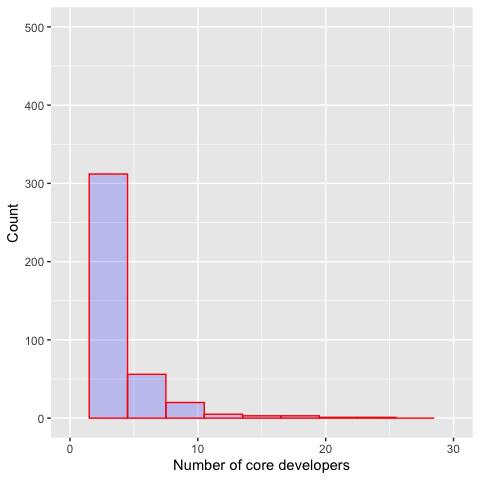

```r
qplot(ds_summary$num_tf,
      geom = "histogram",
      binwidth = 3,
      xlim=c(0,30),
      ylim=c(0, 500),
      fill=I("blue"),
      col=I("red"),
      alpha=I(.2),
      xlab="Number of core developers",
      ylab="Count")
```

Let’s try to understand the women participation on OSS projects.

```r
all_commiters_ds["gender_final"] <-
  ifelse(trim(as.character(all_commiters_ds$gender)) == "", as.character("unknown"), as.character(all_commiters_ds$gender))

tf_ds["gender_final"] <-
  ifelse(as.character(tf_ds$gender) != as.character(tf_ds$gender2), "unknown",  as.character(tf_ds$gender))

# note. we have to remove duplicated data

t_all_commiters <- sqldf("select name, gender_final, count(*) summaryCommiters
                          from all_commiters_ds
                          group by name, gender_final
                          order by 3 desc")


t_tf <- sqldf("select login, user, gender_final, count(*) summaryTF
                       from tf_ds
                       group by login, user, gender_final
                       order by 3 desc")




sqldf("select gender_final, count(*) total from all_commiters_ds group by gender_final")
```

```
##   gender_final  total
## 1       female  12987
## 2         male 208384
## 3       unisex   3873
## 4      unknown  17377
```

```r
sqldf("select gender_final, count(*) total from tf_ds group by gender_final")
```

```
##   gender_final total
## 1          men  1762
## 2      unknown   195
## 3        women    45
```

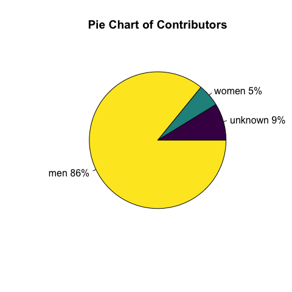

```r
slices <- c(21250, 12987, 208384)
lbls <- c("unknown", "women", "men")
pct <- round(slices/sum(slices)*100)
lbls <- paste(lbls, pct) # add percents to labels
lbls <- paste(lbls,"%",sep="") # ad % to labels

pie(slices, labels=lbls,main="Pie Chart of Contributors", col = viridis(3))
```

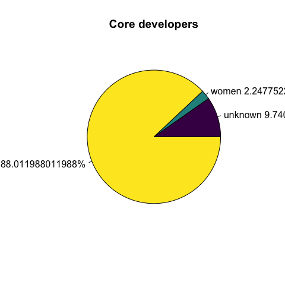

```r
slices <- c(195, 45, 1762)
lbls <- c("unknown", "women", "men")
pct <- slices/sum(slices)*100
lbls <- paste(lbls, pct) # add percents to labels
lbls <- paste(lbls,"%",sep="") # ad % to labels

pie(slices, labels=lbls, main="Core developers", col = viridis(3))
```

That is, the percentage of women core developers is smaller then the percentage of women, when considering all contributors of the projects.

Now, lets group the core developers by language and gender (this produces the Figure 3 of the paper).

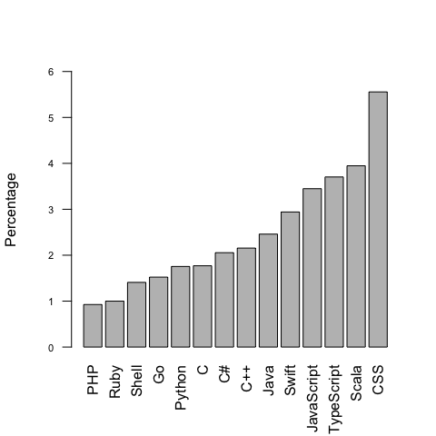

```r
tf_language_women_only <- sqldf("select language, count(*) total_women
                             from tf_ds
                             where gender_final = 'women'
                             group by language");

tf_language <- sqldf("select language, count(*) total
                             from tf_ds
                             group by language")

res <- merge(tf_language, tf_language_women_only)
res["percent"] <- res$total_women * 100 / res$total

res <- res[order(res$percent), ]

barplot(res$percent, names.arg = res$language, las=2, ylab="Percentage", cex.axis = 0.7, ylim=range(pretty(c(0, res$percent))))
```

```r
# dotplot(reorder(res$language, res$percent)~res$language)

# dotplot(res$percent~res$language, las=2)

# dotchart2(res$percent, labels=res$language, las=2, horizontal=F, sort.=T)
```

How many projects have at least one women core developer?

```r
sqldf("select count(distinct full_name) total_projects
                             from tf_ds
                             where gender_final = 'women'");
```

```
##   total_projects
## 1             37
```

Ok, but let us remember the total number of projects.

```r
sqldf("select count(distinct full_name) total_projects
                             from tf_ds");
```

```
##   total_projects
## 1            737
```

Next we present the code for Table 1 in the paper.

```r
head(ds_summary)
```

```
##   language                                         full_name   lines
## 1        C                                     FFmpeg/FFmpeg 1179881
## 2        C                             MarlinFirmware/Marlin  117328
## 3        C SamyPesse/How-to-Make-a-Computer-Operating-System   23443
## 4        C                                   alibaba/tengine  279209
## 5        C                                 allinurl/goaccess   26906
## 6        C                             beanstalkd/beanstalkd    7154
##   num_contributors forks watchers num_tf
## 1             1019  5424    14444     11
## 2              413  6910     5211      1
## 3               35  3127    17933      1
## 4               67  1985     8229      1
## 5               75   624     8676      1
## 6               45   734     5005      1
```

```r
tab1<- sqldf("select language, count(distinct full_name) projects, sum(num_contributors) contributors
       from ds_summary
       group by language")

tab1_kd <- sqldf("select language, count(*) as total_kds
             from tf_ds
             group by language")

tab1_men <- sqldf("select language, count(*) as total_men
             from tf_ds
             where gender_final = 'men'
             group by language")


tab1_women <- sqldf("select language, count(*) as total_women
                 from tf_ds
                 where gender_final = 'women'
                 group by language")


tab1_unknown <- sqldf("select language, count(*) as total_unknown
                 from tf_ds
                 where gender_final = 'unknown'
                 group by language")

tab1_total_projects_with_women <- sqldf("select language, count(distinct full_name) as total_projects_with_women
                 from tf_ds
                 where gender_final = 'women'
                 group by language")

tab1 <- merge(tab1, tab1_kd)

tab1 <- merge(tab1, tab1_men)


tab1 <- merge(tab1, tab1_women)

tab1 <- merge(tab1, tab1_unknown)

tab1 <- merge(tab1, tab1_total_projects_with_women)

tab1["percentage"] <- tab1$total_projects_with_women * 100 / tab1$projects

print(xtable(tab1[,c("language", "projects", "contributors", "total_kds", "total_men", "total_women", "total_unknown", "total_projects_with_women", "percentage")]), type='latex')
```

```
## % latex table generated in R 3.6.1 by xtable 1.8-4 package
## % Mon Jul 27 11:02:41 2020
## \begin{table}[ht]
## \centering
## \begin{tabular}{rlrrrrrrrr}
##   \hline
##  & language & projects & contributors & total\_kds & total\_men & total\_women & total\_unknown & total\_projects\_with\_women & percentage \\
##   \hline
## 1 & C &  50 & 11627.00 & 113 &  99 &   2 &  12 &   2 & 4.00 \\
##   2 & C\# &  63 & 10150.00 & 146 & 129 &   3 &  14 &   3 & 4.76 \\
##   3 & C++ &  67 & 16954.00 & 232 & 191 &   5 &  36 &   3 & 4.48 \\
##   4 & CSS &  23 & 2505.00 &  36 &  30 &   2 &   4 &   2 & 8.70 \\
##   5 & Go &  68 & 19232.00 & 197 & 169 &   3 &  25 &   3 & 4.41 \\
##   6 & Java &  44 & 9575.00 & 122 & 109 &   3 &  10 &   2 & 4.55 \\
##   7 & JavaScript &  67 & 33899.00 & 203 & 172 &   7 &  24 &   5 & 7.46 \\
##   8 & PHP &  46 & 13315.00 & 108 &  98 &   1 &   9 &   1 & 2.17 \\
##   9 & Python &  42 & 20706.00 & 171 & 155 &   3 &  13 &   2 & 4.76 \\
##   10 & Ruby &  60 & 36064.00 & 200 & 183 &   2 &  15 &   2 & 3.33 \\
##   11 & Scala &  57 & 8956.00 & 152 & 137 &   6 &   9 &   5 & 8.77 \\
##   12 & Shell &  24 & 5417.00 &  71 &  63 &   1 &   7 &   1 & 4.17 \\
##   13 & Swift &  36 & 4129.00 &  68 &  59 &   2 &   7 &   2 & 5.56 \\
##   14 & TypeScript &  64 & 20589.00 & 135 & 123 &   5 &   7 &   4 & 6.25 \\
##    \hline
## \end{tabular}
## \end{table}
```

- Total of projects

```r
sum(tab1$projects)
```

```
## [1] 711
```

- Total of contributors

```r
sum(tab1$contributors)
```

```
## [1] 213118
```

- Total of core developers

```r
sum(tab1$total_kds)
```

```
## [1] 1954
```

- Total of men developers

```r
sum(tab1$total_men)
```

```
## [1] 1717
```

- Total of women developers

```r
sum(tab1$total_women)
```

```
## [1] 45
```

- Total of developers that we did not identify the gender

```r
sum(tab1$total_unknown)
```

```
## [1] 192
```

- Total of projects with women core developers

```r
sum(tab1$total_projects_with_women)
```

```
## [1] 37
```

- Average of the percentage of projects with women core developers

```r
mean(tab1$percentage)
```

```
## [1] 5.240598
```

- sd of the percentage ofp projects with women core developers

```r
sd(tab1$percentage)
```

```
## [1] 1.929702
```